# Analyzing the Air Quality in Different New York Boroughs

##### **Natalie Leveque, Greg Ensign**

This data analysis was completed at the University of Maryland - College Park, for an Introduction to Data Science class, CMSC320. This tutorial is intended to lead you through the entire data science pipeline using two different data sets. The first dataset contains air pollution data for different boroughs in New York City. The second data set contains demographic data for the five different boroughs.

Research has shown that many people are disproportionately impacted by air pollution and poor air quality, specifically those in marginalized groups such as people of color, or those who live in low income communities. Exposure to air pollution can cause a myriad of health effects, both short and long term. Among these are strokes, bronchitis, lung cancer, and other respiratory illnesses. To read more about the other adverse health effects of air pollution, click [here](https://www.eea.europa.eu/en/topics/in-depth/air-pollution/eow-it-affects-our-health#:~:text=Both%20short%2D%20and%20long%2Dterm,asthma%20and%20lower%20respiratory%20infections).

The disproportionate effect that air pollution has on these minority communities makes air pollution an environmental justice issue. In this tutorial, we will be analyzing the impact that different factors have on the quantity of air pollution in the different boroughs. Specifically, we will be analyzing demographic data on race and ethnicity, as well as income data, for Brooklyn, Manhattan, Staten Island, Queens and the Bronx. Analyzing this demographic data alongside the air pollution data will help us to identify trends between these variables, and will enable us to recognize whether or not New York City's air pollution problem is also an issue of environmental justice.

#### Step 1: Data Collection

We will be using data from two different sites throughout this tutorial. Our air pollution data was pulled from [this] (https://catalog.data.gov/dataset/air-quality_website), which contains a CSV file. This file tells us about the three different types of air pollution, the boroughs they're located in, and their concentrations. In this section, we will walk you through the steps of data collection, and data cleaning.

```python
import pandas as pd
import numpy as np
import matplotlib.pyplot as plt
from bs4 import BeautifulSoup
import requests
import matplotlib.pyplot as plt
import seaborn as sns
import re
from sklearn import linear_model
from IPython.display import HTML
from scipy import stats

from sklearn.neighbors import KNeighborsClassifier
from sklearn.model_selection import train_test_split
```

Since this is a CSV file, we can use pandas functions to read in the data. However, the raw data from this CSV file contains a lot of extra information that we won't be needing in our analysis, so we have to remove some of the columns to make our data easier to work with. When we're done cleaning the data, we have a dataframe containing the three different types of air pollution, the borough they're found in, the concentration, and the date that the measurement was made. This was all done using Pandas, an extremely powerful library used for data analysis. If you're interested in learning more about Pandas and what it can do, feel free to follow [this](https://www.w3schools.com/python/pandas/pandas_intro.asp) link for more information on how to get started!

```python
# Reading the csv file.
air = pd.read_csv("Air_Quality.csv", sep=',')

#Cuts data down to elements that only describe boroughs, which is the same area that we have demographic data for
air = air[(air['Geo Type Name'] == "Borough")]

#Further cuts data to the most common measurement so that we can compare meaningfully
air = air[(air['Measure Info'] == 'ppb') & (air['Measure'] == 'Mean')]
air.drop(['Unique ID', 'Indicator ID', 'Time Period', 'Message', 'Geo Join ID', 'Measure Info', 'Geo Type Name', 'Measure'], axis=1, inplace=True)
air.rename(columns={'Name':'name', 'Geo Place Name':'area', 'Start_Date':'date', 'Data Value':'ppb'}, inplace=True)
air
```

|  | name | area | date | ppb |
| --- | --- | --- | --- | --- |
| 2 | Ozone (O3) | Bronx | 06/01/2013 | 31.25 |
| 3 | Ozone (O3) | Bronx | 06/01/2014 | 31.15 |
| 6 | Ozone (O3) | Brooklyn | 06/01/2009 | 26.27 |
| 7 | Ozone (O3) | Brooklyn | 06/01/2010 | 33.83 |
| 16 | Ozone (O3) | Brooklyn | 06/01/2011 | 33.19 |
| ... | ... | ... | ... | ... |
| 16083 | Ozone (O3) | Staten Island | 06/01/2020 | 28.61 |
| 16084 | Ozone (O3) | Queens | 06/01/2020 | 30.52 |
| 16085 | Ozone (O3) | Manhattan | 06/01/2020 | 28.77 |
| 16086 | Ozone (O3) | Brooklyn | 06/01/2020 | 29.69 |
| 16087 | Ozone (O3) | Bronx | 06/01/2020 | 30.85 |

280 rows × 4 columns

Now that we've collected air pollution data, we want to collect demographic information. This will help us identify a potential relationship between the demographics of a certain borough, and the concentration of air pollution located in this borough. We scrape the demographic data from Wikipedia, located at [this](https://en.wikipedia.org/wiki/Demographics_of_New_York_City) link. We use the BeautifulSoup library to scrape and clean up this data. The BeautifulSoup library is used for parsing data, specifically data that can be found in a certain format. The data on the Wikipedia page was located in tables, which makes it very easy to scrape using BeautifulSoup. If you want to learn how to scrape data from the web using Beautiful Soup, we've linked a tutorial [here](https://www.geeksforgeeks.org/implementing-web-scraping-python-beautiful-soup/).

```python
# Scraping the data
headers = {
    'User-Agent': 'Mozilla/5.0 (Windows NT 10.0; Win64; x64) AppleWebKit/537.36 (KHTML, like Gecko) Chrome/114.0.0.0 Safari/537.36',
    'From': 'ensigngregory@gmail.com'
}
r = requests.get('https://en.wikipedia.org/wiki/Demographics_of_New_York_City', headers=headers)
root = BeautifulSoup(r.content)
root.prettify()
tablelist = root.find_all("table")

# Grabbing the desired table from the data
demo = pd.read_html(str(tablelist[6]))[0]

# Removing unused rows and columns
demo.drop(demo.index[6:], inplace=True)
demo.drop(demo.index[0], inplace=True)
demo.drop(demo.columns[8:], axis=1, inplace=True)
```

A few things to note about the data that we are using

1. The 'other' data column includes: American Indian, Native Alaskan, Native Hawaiian, Pacific Islander's and mixed race individuals
2. You may notice that the rows add up to over 100%. This is because hispanic is considered an ethnicity. Therefore, the percentage listed for the hispanic column is considered a percentage of the total population.

After scraping the data from the wikipedia page, we will need to clean it up a bit so that it is easy to work with. First, we will rename the columns of our data, and change the data types. When we're finished, we will have a table that lists each borough and its total population, and what percentage of the population is made up of each race or ethnicity.

```python
demo.rename(columns={'Jurisdiction':'area','Population 2000 census':'population','% white':'white', '% black or African American':'black', '% Asian':'asian', '% Hispanic/ Latino of any race': 'hispanic',
                    '% Other':'other','% mixed race':'mixed'}, inplace=True)

# Changing the data type of each row so that we can do math with them
for index, row in demo.iterrows():
    row['white'] = float(row['white'])
    row['black'] = float(row['black'])
    row['asian'] = float(row['asian'])
    row['hispanic'] = float(row['hispanic'])
    row['other'] = float(row['other'])
    row['mixed'] = float(row['mixed'])
    row['population'] = int(row['population'])

# Combining the other/mixed columns into one column
demo['other'] = demo['other'] + demo ['mixed']

# Removing the mixed column because it is now included in the 'other' column
demo.drop(demo.columns[6],axis=1,inplace=True)

demo
```

|  | area | population | white | black | asian | other | hispanic |
| --- | --- | --- | --- | --- | --- | --- | --- |
| 1 | Brooklyn | 2465326 | 41.2 | 36.4 | 7.5 | 14.9 | 19.8 |
| 2 | Queens | 2229379 | 44.1 | 20.0 | 17.6 | 18.4 | 25.0 |
| 3 | Manhattan | 1537195 | 54.4 | 17.4 | 9.4 | 18.8 | 27.2 |
| 4 | Bronx | 1332650 | 29.9 | 35.6 | 3.0 | 31.5 | 48.4 |
| 5 | Staten Island | 443728 | 77.6 | 9.7 | 5.7 | 7.0 | 12.1 |

In addition to the racial/ethnic demographic data, we also scraped income data on each borough in New York City. The mean and median column in this dataframe indicate household income, and the poverty column indicates what percentage of each borough is impoverished.

```python
# Pulling the income level table from the wikipedia page
income = pd.read_html(str(tablelist[8]))[0]

# Removing the botton rows from the dataframe
income.drop(income.index[5:], inplace=True)
income.rename(columns={'Area':'area', 'Median House- hold Income':'median', 'Mean House- hold Income':'mean', 'Percent- age in Poverty':'poverty'}, inplace=True)
for index, row in income.iterrows():
    row['median'] = row['median'][1:]
    row['mean'] = row['mean'][1:]
    row['poverty'] = row['poverty'][:-1]

income
```

|  | area | median | mean | poverty |
| --- | --- | --- | --- | --- |
| 0 | The Bronx | 34,156 | 46,298 | 27.1 |
| 1 | Brooklyn | 41,406 | 60,020 | 21.9 |
| 2 | Manhattan | 64,217 | 121,549 | 17.6 |
| 3 | Queens | 53,171 | 67,027 | 12.0 |
| 4 | Staten Island | 66,985 | 81,498 | 9.8 |

#### Step 2: Data Analysis and Visualization

In this section, we're going to graph and plot the data. This will let us visualize the trends that are present in the data, and also help us understand the data better. First, we're going to plot the contents of each table separately. We'll start with the one that indicates the pollution levels in each borough.

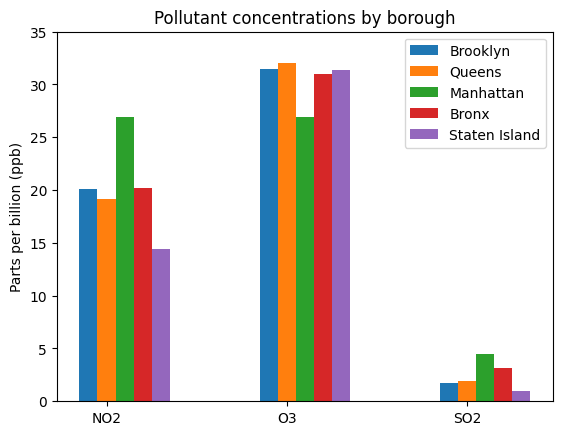

```python
grouped = air.groupby(['name', 'area'])['ppb'].mean().reset_index()
grouped

pollutants = ('NO2', 'O3', 'SO2')
means = {
    "Brooklyn":grouped.loc[(grouped['area'] == 'Brooklyn')],
    "Queens":grouped.loc[(grouped['area'] == 'Queens')],
    "Manhattan":grouped.loc[(grouped['area'] == 'Manhattan')],
    "Bronx":grouped.loc[(grouped['area'] == 'Bronx')],
    "Staten Island":grouped.loc[(grouped['area'] == 'Staten Island')]
}
width = 0.1
m = 0
x = np.arange(3)

fig, ax = plt.subplots()
for attribute, ppb in means.items():
    ppb = ppb.reset_index()['ppb']
    offset = width * m
    bars = ax.bar(x + offset, ppb, width, label=attribute)
    m += 1

ax.set_ylabel('Parts per billion (ppb)')
ax.set_title('Pollutant concentrations by borough')
ax.set_xticks(x + width, pollutants)
ax.legend(loc='upper right')
ax.set_ylim(0, 35)

plt.show()
```

As you can see, there are three different types of pollutants which are found in the different boroughs. These are NO2, 03, and SO2, or Nitrogen dioxide, ozone, and Sulphur dioxide.

Nitrogen dioxide is a pollutant formed by motor vehicle emissions, and is typically found in areas with lots of traffic. NO2 exposure has several potential health effects, like increased susceptibility to lung infections, and airway inflammation.

Ozone, or O3, is found in Earth's upper atmosphere, and at ground level. In the upper atmosphere, 03 protects us from UV radiation from the sun. However, at the ground level, ozone is damaging to our health. Potential health effects from ozone exposure include eye and throat irritation, as well as reduced lung function. Ozone also continues to damage lungs even when symptoms aren't present.

Sulphur dioxide is formed at power plants or industrial facilities. Exposure to SO2 can cause asthma attacks, as well as chest tightness and shortness of breath.

Information on these pollutants was gathered from [this](https://www.health.nsw.gov.au/environment/air/Pages/common-air-pollutants.aspx) website.

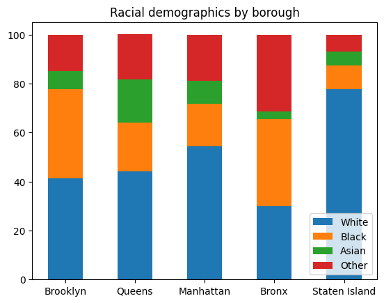

```python
width = 0.5

fig, ax = plt.subplots()
bottom = np.zeros(5)

counts = {
    "White": demo['white'],
    "Black": demo['black'],
    "Asian": demo['asian'],
    "Other": demo['other']
}

for boolean, count in counts.items():
    p = ax.bar(demo['area'], count, width, label=boolean, bottom=bottom)
    bottom += count

ax.set_title("Racial demographics by borough")
ax.legend(loc="lower right")
plt.show()
```

Now that we've condensed the air pollution data, we will plot the demographic data. For this dataset, there was several things to think about. First, race and ethnicity are considered separate entities when accounting for percentage of the population. Hispanic is the only ethnicity listed in our table, because it is included in the racial data. Therefore, we decided to display one plot listing the percentages of each race present in the different boroughs, and then make 5 separate plots listing the population (in millions) of each race or ethnicity in the 5 different boroughs.

```
2465326
2229379
1537195
1332650
443728
```

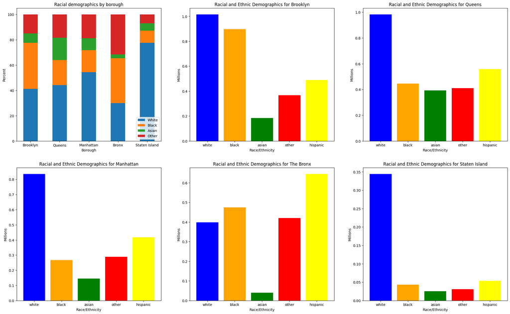

```python
# Make five plots, one for each borough. Show the total population and calculate the exact population number each race/ethnicity makes up
# of that total population. Therefore, this should be a bar graph.

# Creating and formatting the subplots
fig, axs = plt.subplots(2,3)
fig.set_size_inches(25,15)
width = 0.5
bottom = np.zeros(5)
axs[0,0].set_title("Racial demographics by borough")
axs[0,1].set_title("Racial and Ethnic Demographics for Brooklyn")
axs[0,2].set_title("Racial and Ethnic Demographics for Queens")
axs[1,0].set_title("Racial and Ethnic Demographics for Manhattan")
axs[1,1].set_title("Racial and Ethnic Demographics for The Bronx")
axs[1,2].set_title("Racial and Ethnic Demographics for Staten Island")

# Plotting the Racial Demographics Data
counts = {
    "White": demo['white'],
    "Black": demo['black'],
    "Asian": demo['asian'],
    "Other": demo['other']
}
for boolean, count in counts.items():
    p = axs[0,0].bar(demo['area'], count, width, label=boolean, bottom=bottom)
    bottom += count

# Making the other five plots

pops = {'Brooklyn':[],'Queens':[],'Manhattan':[],'Bronx':[],'Staten Island':[]}

for index, row in demo.iterrows():
    print(row[1])
    pops[row[0]].append(((row['white']/100)*row[1])/1000000)
    pops[row[0]].append(((row['black']/100)*row[1])/1000000)
    pops[row[0]].append(((row['asian']/100)*row[1])/1000000)
    pops[row[0]].append(((row['other']/100)*row[1])/1000000)
    pops[row[0]].append(((row['hispanic']/100)*row[1])/1000000)


axs[0,1].bar(x = ['white','black','asian','other','hispanic'], height = pops['Brooklyn'],color=['blue','orange','green','red','yellow'])
axs[0,2].bar(x = ['white','black','asian','other','hispanic'], height = pops['Queens'],color=['blue','orange','green','red','yellow'])
axs[1,0].bar(x = ['white','black','asian','other','hispanic'], height = pops['Manhattan'],color=['blue','orange','green','red','yellow'])
axs[1,1].bar(x = ['white','black','asian','other','hispanic'], height = pops['Bronx'],color=['blue','orange','green','red','yellow'])
axs[1,2].bar(x = ['white','black','asian','other','hispanic'], height = pops['Staten Island'],color=['blue','orange','green','red','yellow'])

axs[0,0].set_xlabel("Borough")
axs[0,0].set_ylabel("Percent")

axs[0,1].set_xlabel("Race/Ethnicity")
axs[0,1].set_ylabel("Millions")

axs[0,2].set_xlabel("Race/Ethnicity")
axs[0,2].set_ylabel("Millions")

axs[1,0].set_xlabel("Race/Ethnicity")
axs[1,0].set_ylabel("Millions")

axs[1,1].set_xlabel("Race/Ethnicity")
axs[1,1].set_ylabel("Millions")

axs[1,2].set_xlabel("Race/Ethnicity")
axs[1,2].set_ylabel("Millions")

axs[0,0].legend(loc="lower right")
plt.show()
```

Now that we have visualized all of our data, we will plot the proportion of a marginalized group located in each borough against the concentration of pollutants. This will help us identify whether or not air pollution in New York City is an environmental justice issue or not, if the data shows that minorities or marginalized groups are disproportionately affected by pollution.

To identify these trends, we use linear regression with minority proportion or poverty level in each borough as the x axis and the concentration of each pollutant on the y axis. The linear regression will find a line of best fit, indicating a trend between the two different variables.

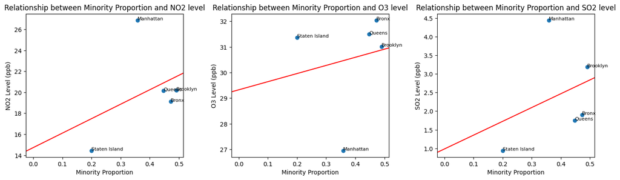

```python
fig, axs = plt.subplots(1,3)
fig.set_size_inches(15,5)
width = 0.5
fig.tight_layout(pad=5)
min_percent = []
for p in pops.keys():
    cur = pd.Series(pops[p])
    min_percent.append((cur.sum()-cur[0]-cur[4])/cur.sum())

axs[0].scatter(min_percent, grouped.loc[(grouped['name'] == 'Nitrogen Dioxide (NO2)')]['ppb'])
m, b = np.polyfit(min_percent, grouped.loc[(grouped['name'] == 'Nitrogen Dioxide (NO2)')]['ppb'], 1)
for i, txt in enumerate(list(pops.keys())):
    axs[0].annotate(txt,(min_percent[i],grouped.loc[(grouped['name'] == 'Nitrogen Dioxide (NO2)')]['ppb'][i]),size=8)

axs[0].axline((0, b), slope=m, color="red")
axs[0].set_title("Relationship between Minority Proportion and NO2 level")
axs[0].set_xlabel("Minority Proportion")
axs[0].set_ylabel("NO2 Level (ppb)")

axs[1].scatter(min_percent, grouped.loc[(grouped['name'] == 'Ozone (O3)')]['ppb'])
m, b = np.polyfit(min_percent, grouped.loc[(grouped['name'] == 'Ozone (O3)')]['ppb'], 1)
for i, txt in enumerate(list(pops.keys())):

    axs[1].annotate(txt,(min_percent[i],grouped.loc[(grouped['name'] == 'Ozone (O3)')]['ppb'][i+5]),size=8)

axs[1].axline((0, b), slope=m, color="red")
axs[1].set_title("Relationship between Minority Proportion and O3 level")
axs[1].set_xlabel("Minority Proportion")
axs[1].set_ylabel("O3 Level (ppb)")

axs[2].scatter(min_percent, grouped.loc[(grouped['name'] == 'Sulfur Dioxide (SO2)')]['ppb'])
m, b = np.polyfit(min_percent, grouped.loc[(grouped['name'] == 'Sulfur Dioxide (SO2)')]['ppb'], 1)
for i, txt in enumerate(list(pops.keys())):

    axs[2].annotate(txt,(min_percent[i],grouped.loc[(grouped['name'] == 'Sulfur Dioxide (SO2)')]['ppb'][i+10]),size=8)


axs[2].axline((0, b), slope=m, color="red")
axs[2].set_title("Relationship between Minority Proportion and SO2 level")
axs[2].set_xlabel("Minority Proportion")
axs[2].set_ylabel("SO2 Level (ppb)")
plt.show()
```

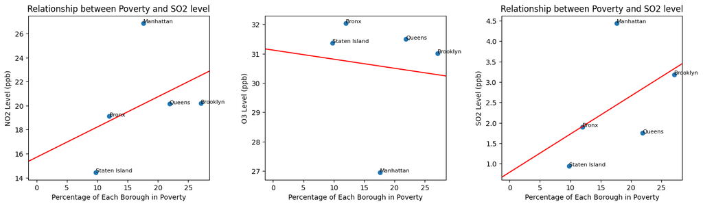

```python
fig, axs = plt.subplots(1,3)
fig.set_size_inches(15,5)
fig.tight_layout(pad=5)
width = 0.5


for index, row in income.iterrows():
    row['poverty'] = float(row['poverty'])

axs[0].scatter(income['poverty'], grouped.loc[(grouped['name'] == 'Nitrogen Dioxide (NO2)')]['ppb'])
m, b = np.polyfit(list(income['poverty']), grouped.loc[(grouped['name'] == 'Nitrogen Dioxide (NO2)')]['ppb'], 1)
for i, txt in enumerate(list(pops.keys())):

    axs[0].annotate(txt,(income['poverty'][i],grouped.loc[(grouped['name'] == 'Nitrogen Dioxide (NO2)')]['ppb'][i]),size=8)

axs[0].axline((0, b), slope=m, color="red")
axs[0].set_title("Relationship between Poverty and SO2 level")
axs[0].set_xlabel("Percentage of Each Borough in Poverty")
axs[0].set_ylabel("NO2 Level (ppb)")

axs[1].scatter(income['poverty'], grouped.loc[(grouped['name'] == 'Ozone (O3)')]['ppb'])
m, b = np.polyfit(list(income['poverty']), grouped.loc[(grouped['name'] == 'Ozone (O3)')]['ppb'], 1)
for i, txt in enumerate(list(pops.keys())):

    axs[1].annotate(txt,(income['poverty'][i],grouped.loc[(grouped['name'] == 'Ozone (O3)')]['ppb'][i+5]),size=8)


axs[1].axline((0, b), slope=m, color="red")
axs[2].set_title("Relationship between Poverty and SO2 level")
axs[1].set_xlabel("Percentage of Each Borough in Poverty")
axs[1].set_ylabel("O3 Level (ppb)")

axs[2].scatter(income['poverty'], grouped.loc[(grouped['name'] == 'Sulfur Dioxide (SO2)')]['ppb'])
m, b = np.polyfit(list(income['poverty']), grouped.loc[(grouped['name'] == 'Sulfur Dioxide (SO2)')]['ppb'], 1)
for i, txt in enumerate(list(pops.keys())):

    axs[2].annotate(txt,(income['poverty'][i],grouped.loc[(grouped['name'] == 'Sulfur Dioxide (SO2)')]['ppb'][i+10]),size=8)

axs[2].axline((0, b), slope=m, color="red")
axs[2].set_title("Relationship between Poverty and SO2 level")
axs[2].set_xlabel("Percentage of Each Borough in Poverty")
axs[2].set_ylabel("SO2 Level (ppb)")
plt.show()
```

#### Interpretation

We also analyzed poverty levels for each borough by calculating what percentage of each borough is in poverty, and seeing how this affects the amount of air pollution found in that borough. We found a positive relationship between poverty levels and pollution level for SO2 and NO2, however O3 had a slight negative relationship. However, for the majority of the boroughs, it was clear that higher poverty levels lead to higher pollution levels,

Both of these trends that we found in the data is indicative of an environmental justice issue present in New York City. It is unfair that certain people are subject to harmful toxins simply because of where they live or their circumstances, and are likely suffering from adverse health effects because of it. If you want to learn more about how air pollution is disproportionately affecting marginalized groups in New York City, feel free to learn more at the following links:

[What To Know](https://spectrumlocalnews.com/nys/capital-region/news/2023/02/25/shining-a-light-on-issue-of-environmental-justice-across-new-york-state)

[How To Help](https://www.weact.org/whatwedo/areasofwork/cleanair/)

Thank you for reading our tutorial!